# King County, House Price Prediction

Andrew Rizk

26-05-2019

[figure not shown]

#### Github link

https://github.com/andrewrizk/kc-house-price

#### 1. Introduction

In this following practice, we will attempt to predict house prices in King Country in Seattle based on the House Prices Dataset on Kaggle: https://www.kaggle.com/harlfoxem/housesalesprediction. It includes homes sold between May 2014 and May 2015.

The dataset presents different features of the houses that variably change the predictions. The data will require some work for cleaning and preprocessing to be ready for modeling.

The steps of this practice will involve: 1 - Data cleaning and preprocessing. 2 - Exploratory data analysis. 3 - Feature Engineering: this will involve transforming variables, creating new variables, and eliminating variables in favor of our predictions. 4 - Correlations 5 - Removing Outliers/Scaling/Adjusting Skewness 6 - Modeling: a. Linear Regressions b. Ridge Regression c. Lasso Regression d. XGBoost e. Random Forest 7 - Model Comparison

- Final model was selected as XGBoost with a MAPE of 0.114 *

#### 2. Load Libraries

#### 2. Load Datasets

We will first load the datasets and create a price column for the test set so we can combine them together for further preprocessing.

```
## The train set has  17277 rows and  22 columns,
```

```
## The test set has  4320 rows and  22 columns,
```

```
## The combined dataset has  21597 rows and  22 columns
```

#### 3. Feature Removal

We can identify some features that don’t add any value to the dataset due to their nature. The variable ‘Id’ is a key and will not have any impact in the final predicion. Other features will be removed later after the feature engineering process.

#### 4. NA Discovery

We need to clean NA values in all the columns and impute null values (if present). First, we explore which columns have missing values.

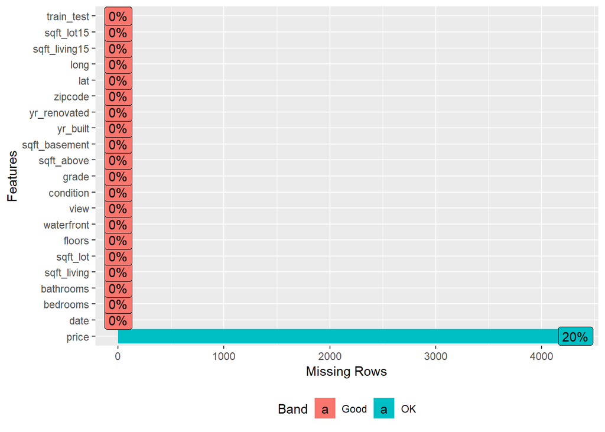

```
## [1] "There are 1 columns with missing values"
```

```
## price
##  4320
```

#### 5. Data Structure

Discovering the data structure and a quantitative summary of the variables.

```
## 'data.frame':    21597 obs. of  21 variables:
##  $ date         : Factor w/ 372 levels "1/10/2015","1/12/2015",..: 211 331 290 20 226 223 94 34 76 294 ...
##  $ price        : num  225000 641250 810000 330000 530000 ...
##  $ bedrooms     : int  3 3 4 4 4 4 4 3 4 3 ...
##  $ bathrooms    : num  1.5 2.5 3.5 1.5 1.75 3.5 3.25 2.25 2.5 1.5 ...
##  $ sqft_living  : int  1250 2220 3980 1890 1814 3120 4160 1440 2250 2540 ...
##  $ sqft_lot     : int  7500 2550 209523 7540 5000 5086 47480 10500 6840 9520 ...
##  $ floors       : num  1 3 2 1 1 2 2 1 2 1 ...
##  $ waterfront   : int  0 0 0 0 0 0 0 0 0 0 ...
##  $ view         : int  0 2 2 0 0 0 0 0 0 0 ...
##  $ condition    : int  3 3 3 4 4 3 3 3 3 3 ...
##  $ grade        : int  7 10 9 7 7 9 10 8 9 8 ...
##  $ sqft_above   : int  1250 2220 3980 1890 944 2480 4160 1130 2250 1500 ...
##  $ sqft_basement: int  0 0 0 0 870 640 0 310 0 1040 ...
##  $ yr_built     : int  1967 1990 2006 1967 1951 2008 1995 1983 1987 1959 ...
##  $ yr_renovated : int  0 0 0 0 0 0 0 0 0 0 ...
##  $ zipcode      : int  98030 98117 98024 98155 98115 98115 98072 98023 98058 98115 ...
##  $ lat          : num  47.4 47.7 47.6 47.8 47.7 ...
##  $ long         : num  -122 -122 -122 -122 -122 ...
##  $ sqft_living15: int  1260 2200 2220 1890 1290 1880 3400 1510 2480 1870 ...
##  $ sqft_lot15   : int  7563 5610 65775 8515 5000 5092 40428 8125 7386 6800 ...
##  $ train_test   : chr  "train" "train" "train" "train" ...
```

```
##         date           price            bedrooms        bathrooms
##  6/23/2014:  142   Min.   :  78000   Min.   : 1.000   Min.   :0.500
##  6/25/2014:  131   1st Qu.: 320000   1st Qu.: 3.000   1st Qu.:1.750
##  6/26/2014:  131   Median : 450000   Median : 3.000   Median :2.250
##  7/8/2014 :  127   Mean   : 539865   Mean   : 3.373   Mean   :2.116
##  4/27/2015:  126   3rd Qu.: 645500   3rd Qu.: 4.000   3rd Qu.:2.500
##  3/25/2015:  123   Max.   :7700000   Max.   :33.000   Max.   :8.000
##  (Other)  :20817   NA's   :4320
##   sqft_living       sqft_lot           floors        waterfront
##  Min.   :  370   Min.   :    520   Min.   :1.000   Min.   :0.000000
##  1st Qu.: 1430   1st Qu.:   5040   1st Qu.:1.000   1st Qu.:0.000000
##  Median : 1910   Median :   7618   Median :1.500   Median :0.000000
##  Mean   : 2080   Mean   :  15099   Mean   :1.494   Mean   :0.007547
##  3rd Qu.: 2550   3rd Qu.:  10685   3rd Qu.:2.000   3rd Qu.:0.000000
##  Max.   :13540   Max.   :1651359   Max.   :3.500   Max.   :1.000000
##
##       view          condition        grade          sqft_above
##  Min.   :0.0000   Min.   :1.00   Min.   : 3.000   Min.   : 370
##  1st Qu.:0.0000   1st Qu.:3.00   1st Qu.: 7.000   1st Qu.:1190
##  Median :0.0000   Median :3.00   Median : 7.000   Median :1560
##  Mean   :0.2343   Mean   :3.41   Mean   : 7.658   Mean   :1789
##  3rd Qu.:0.0000   3rd Qu.:4.00   3rd Qu.: 8.000   3rd Qu.:2210
##  Max.   :4.0000   Max.   :5.00   Max.   :13.000   Max.   :9410
##
##  sqft_basement       yr_built     yr_renovated        zipcode
##  Min.   :   0.0   Min.   :1900   Min.   :   0.00   Min.   :98001
##  1st Qu.:   0.0   1st Qu.:1951   1st Qu.:   0.00   1st Qu.:98033
##  Median :   0.0   Median :1975   Median :   0.00   Median :98065
##  Mean   : 291.7   Mean   :1971   Mean   :  84.46   Mean   :98078
##  3rd Qu.: 560.0   3rd Qu.:1997   3rd Qu.:   0.00   3rd Qu.:98118
##  Max.   :4820.0   Max.   :2015   Max.   :2015.00   Max.   :98199
##
##       lat             long        sqft_living15    sqft_lot15
##  Min.   :47.16   Min.   :-122.5   Min.   : 399   Min.   :   651
##  1st Qu.:47.47   1st Qu.:-122.3   1st Qu.:1490   1st Qu.:  5100
##  Median :47.57   Median :-122.2   Median :1840   Median :  7620
##  Mean   :47.56   Mean   :-122.2   Mean   :1987   Mean   : 12758
##  3rd Qu.:47.68   3rd Qu.:-122.1   3rd Qu.:2360   3rd Qu.: 10083
##  Max.   :47.78   Max.   :-121.3   Max.   :6210   Max.   :871200
##
##   train_test
##  Length:21597
##  Class :character
##  Mode  :character
##
##
##
##
```

#### 6. Factorize Numerical to Categories

There are some numerical features that should be factorized as categorical ones, in order to gasp correctly the information inside those columns. If we analyze some features we will see that we have categorical values encoded as numeric. We will transform some of those into factors since they wont be used in any calculation. Note that some features will be factorized later after the EDA process.

#### 7. EDA

```
## 'data.frame':    21597 obs. of  21 variables:
##  $ date         : Factor w/ 372 levels "1/10/2015","1/12/2015",..: 211 331 290 20 226 223 94 34 76 294 ...
##  $ price        : num  225000 641250 810000 330000 530000 ...
##  $ bedrooms     : int  3 3 4 4 4 4 4 3 4 3 ...
##  $ bathrooms    : num  1.5 2.5 3.5 1.5 1.75 3.5 3.25 2.25 2.5 1.5 ...
##  $ sqft_living  : int  1250 2220 3980 1890 1814 3120 4160 1440 2250 2540 ...
##  $ sqft_lot     : int  7500 2550 209523 7540 5000 5086 47480 10500 6840 9520 ...
##  $ floors       : num  1 3 2 1 1 2 2 1 2 1 ...
##  $ waterfront   : Factor w/ 2 levels "0","1": 1 1 1 1 1 1 1 1 1 1 ...
##  $ view         : int  0 2 2 0 0 0 0 0 0 0 ...
##  $ condition    : Factor w/ 5 levels "1","2","3","4",..: 3 3 3 4 4 3 3 3 3 3 ...
##  $ grade        : Factor w/ 11 levels "3","4","5","6",..: 5 8 7 5 5 7 8 6 7 6 ...
##  $ sqft_above   : int  1250 2220 3980 1890 944 2480 4160 1130 2250 1500 ...
##  $ sqft_basement: int  0 0 0 0 870 640 0 310 0 1040 ...
##  $ yr_built     : int  1967 1990 2006 1967 1951 2008 1995 1983 1987 1959 ...
##  $ yr_renovated : int  0 0 0 0 0 0 0 0 0 0 ...
##  $ zipcode      : Factor w/ 70 levels "98001","98002",..: 19 52 15 63 50 50 37 14 33 50 ...
##  $ lat          : num  47.4 47.7 47.6 47.8 47.7 ...
##  $ long         : num  -122 -122 -122 -122 -122 ...
##  $ sqft_living15: int  1260 2200 2220 1890 1290 1880 3400 1510 2480 1870 ...
##  $ sqft_lot15   : int  7563 5610 65775 8515 5000 5092 40428 8125 7386 6800 ...
##  $ train_test   : chr  "train" "train" "train" "train" ...
```

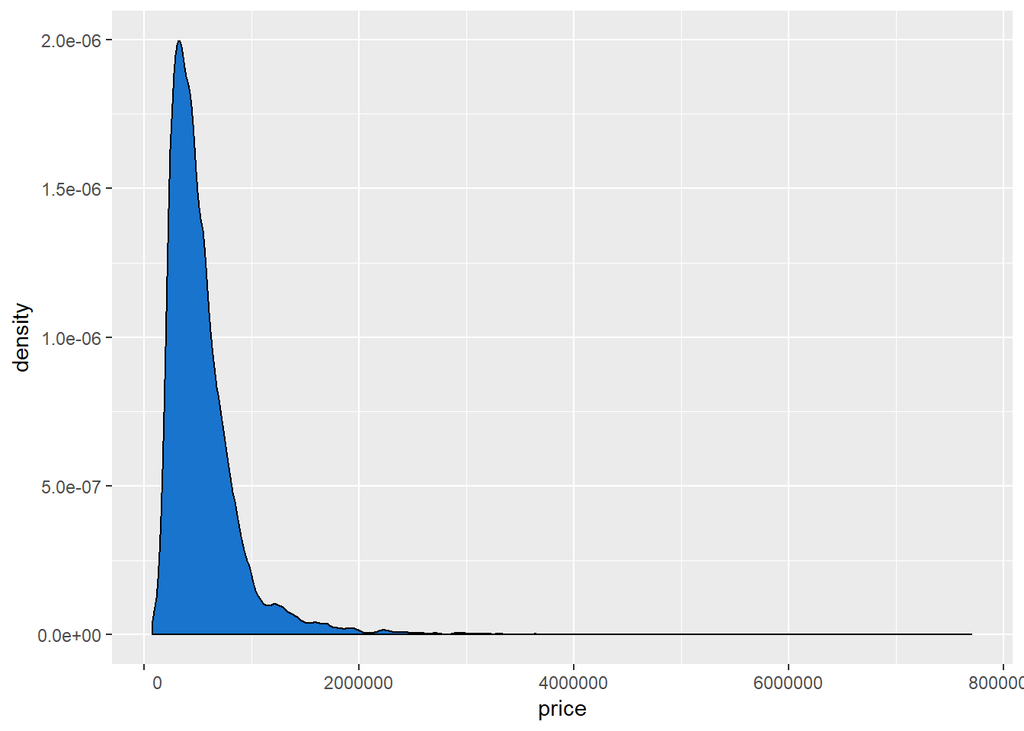

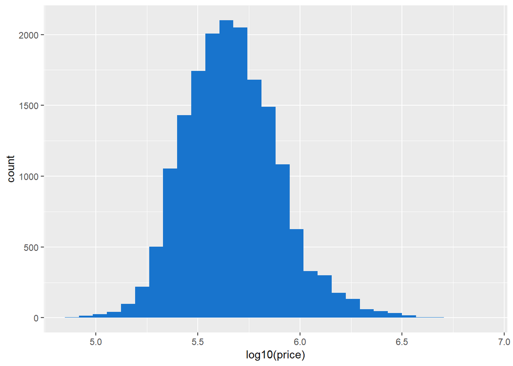

We will now create a new column to categorize the prices into 4 categories (Cheap, Medium, Expensive, Very Expensive) and visualize the results using leaflet. Though since the code below really slows down my Rmarkdown, I decided to comment it out.

##### 7.1 Visual Representations (All Variables vs Price)

We will now visualize each numeric feature with the target variable to see how the price varies with the variation in the independent variables.

```
##  [1] "id"            "price"         "bedrooms"      "bathrooms"
##  [5] "sqft_living"   "sqft_lot"      "floors"        "waterfront"
##  [9] "view"          "condition"     "grade"         "sqft_above"
## [13] "sqft_basement" "yr_built"      "yr_renovated"  "zipcode"
## [17] "lat"           "long"          "sqft_living15" "sqft_lot15"
```

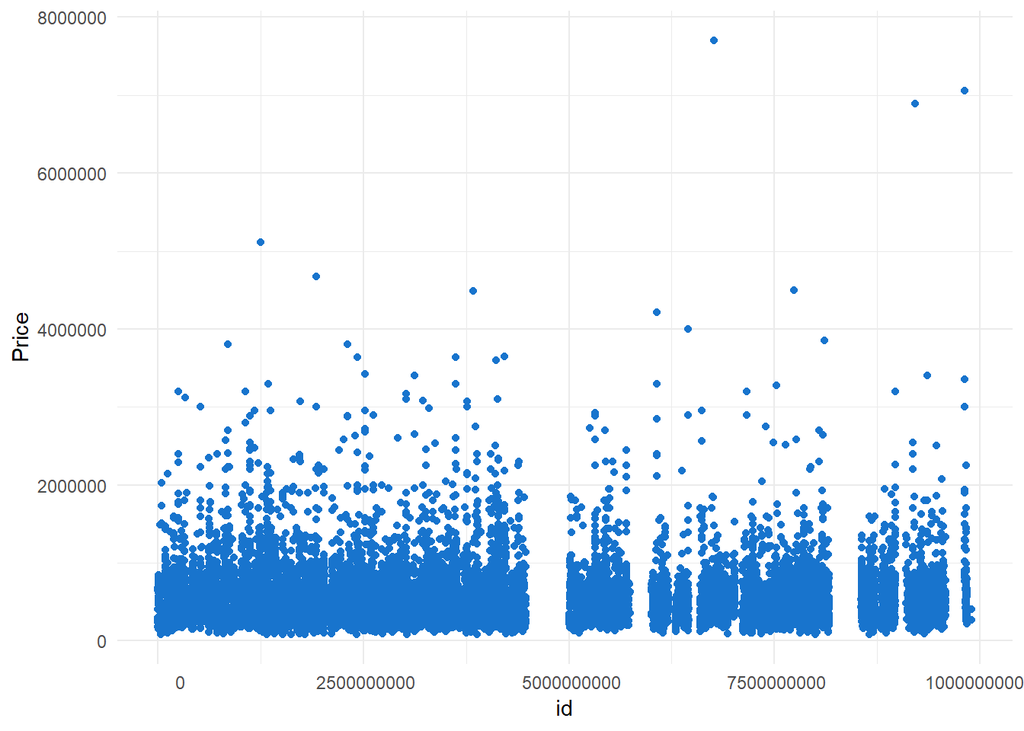

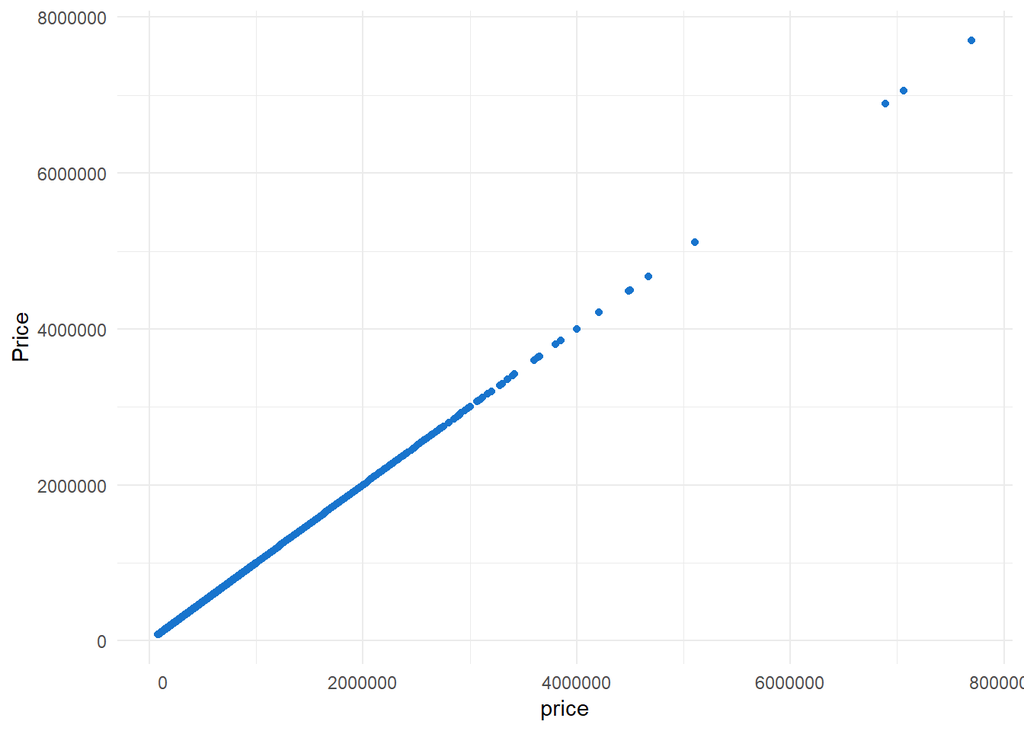

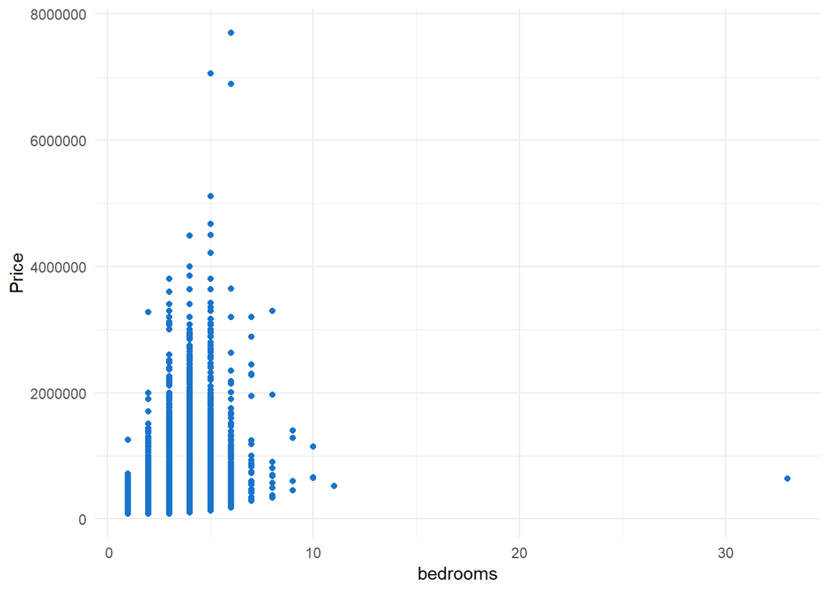

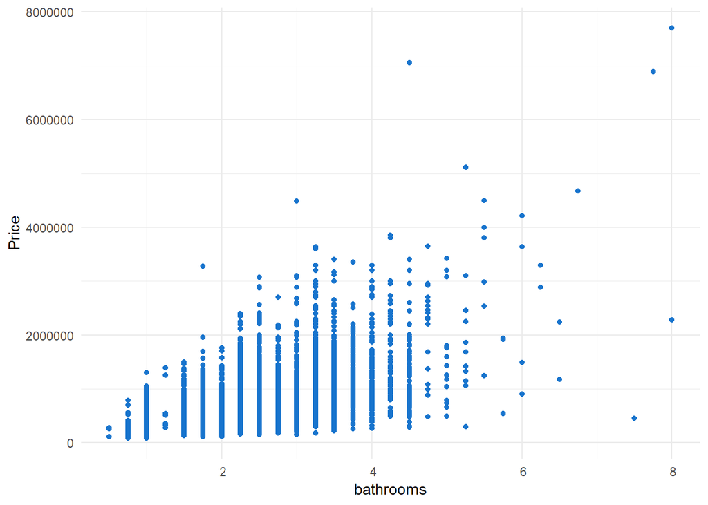

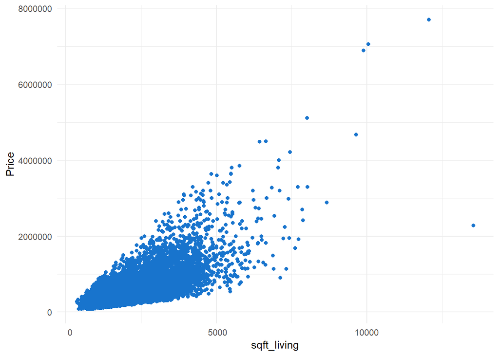

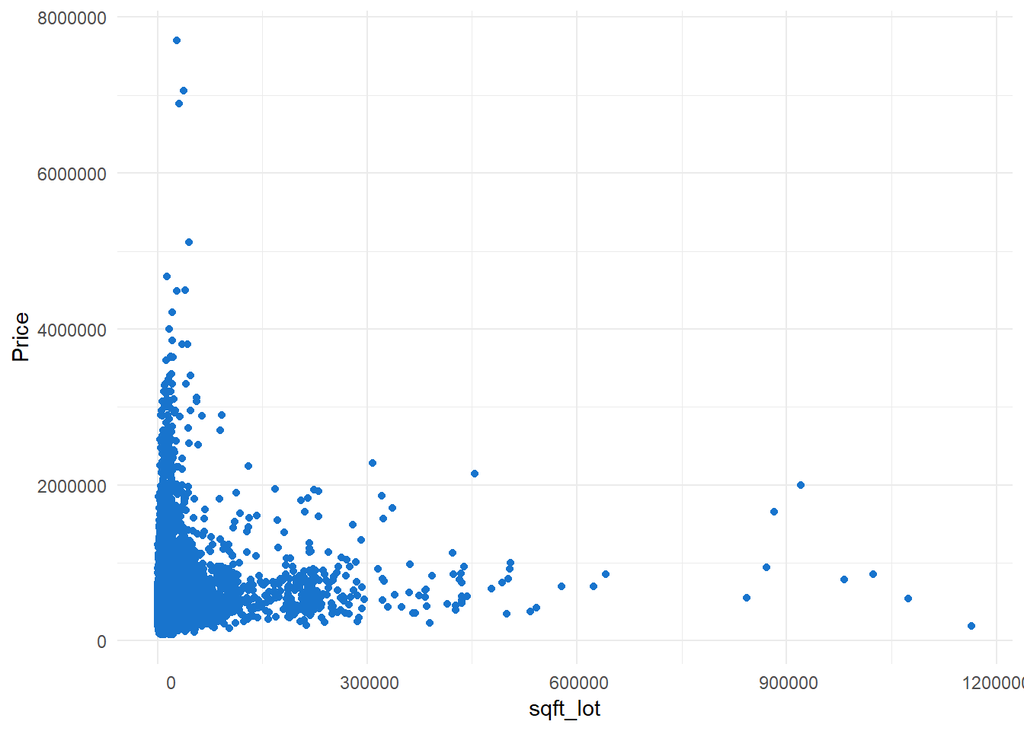

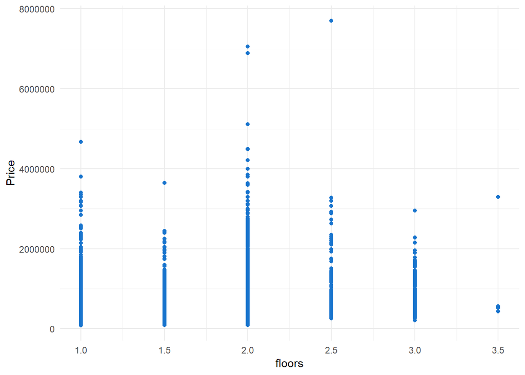

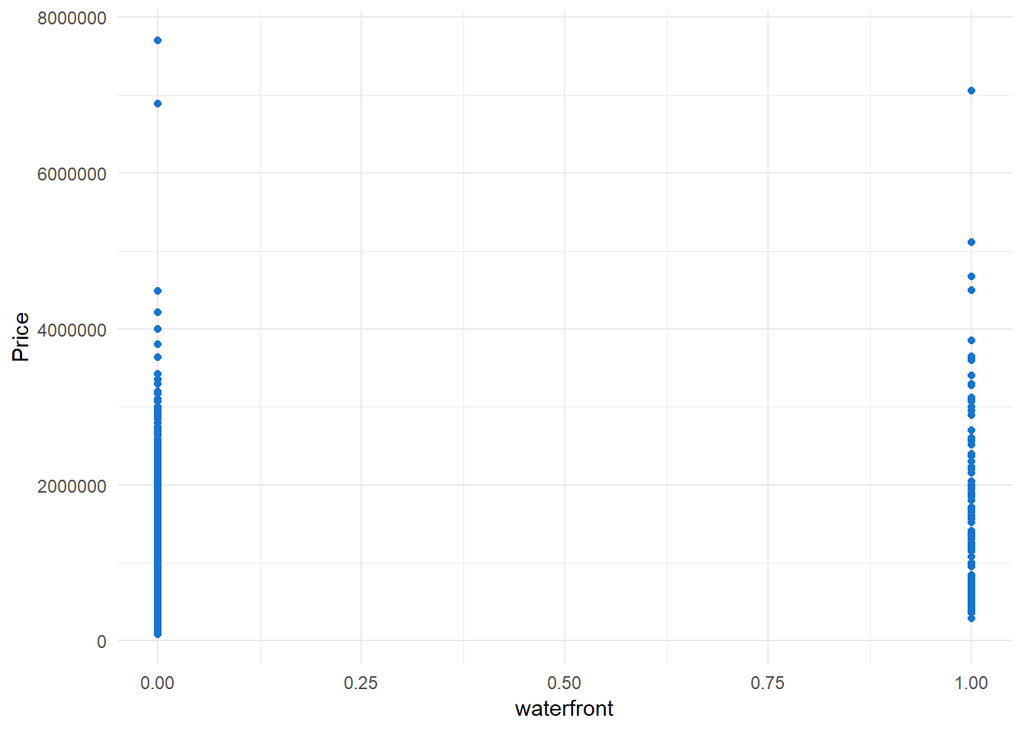

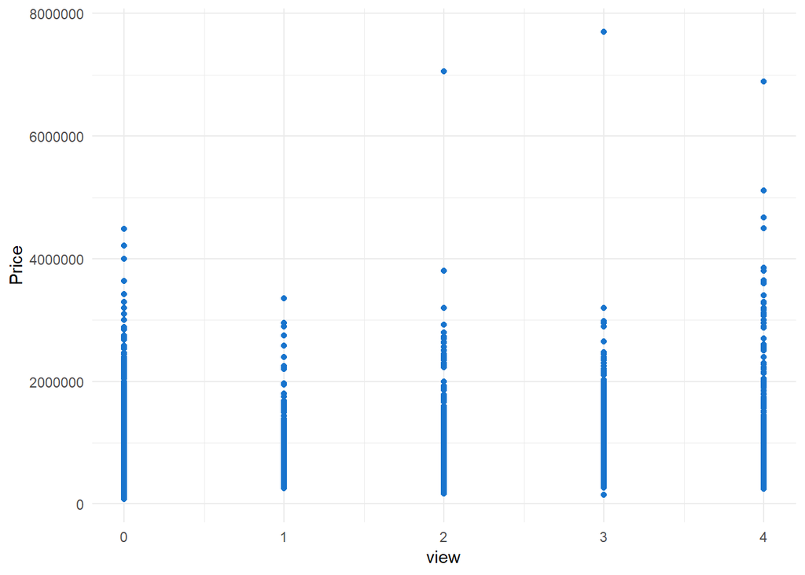

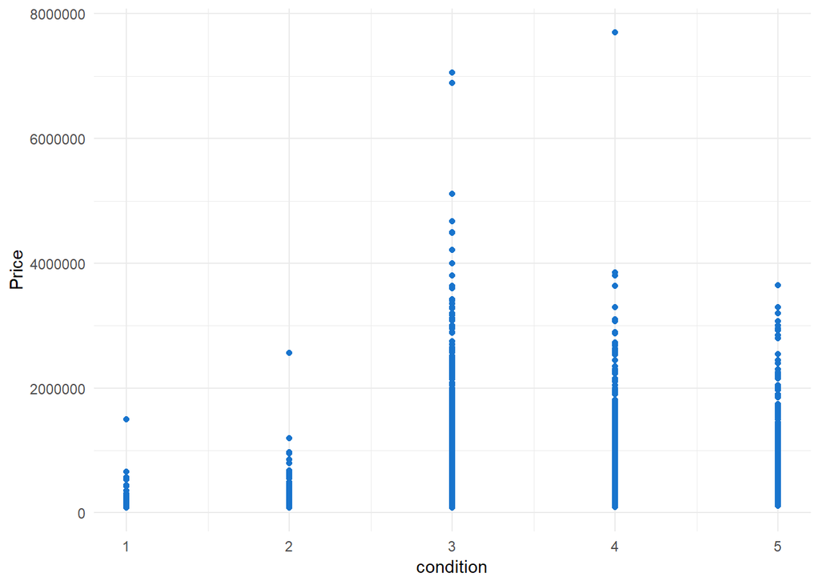

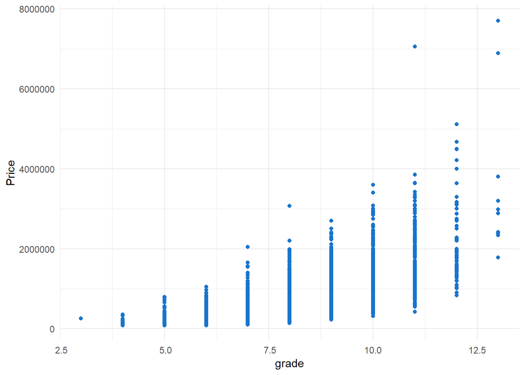

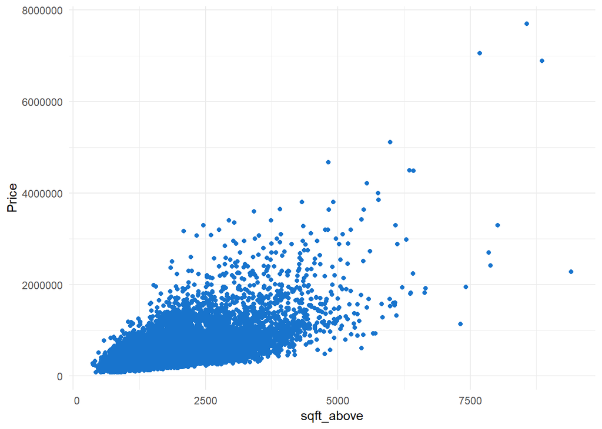

[8 more figures not shown]

```
##
##    1    2    3    4    5    6    7    8    9   10   11   33
##  196 2760 9824 6882 1601  272   38   13    6    3    1    1
```

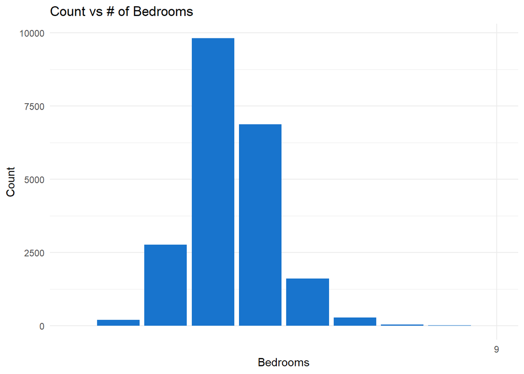

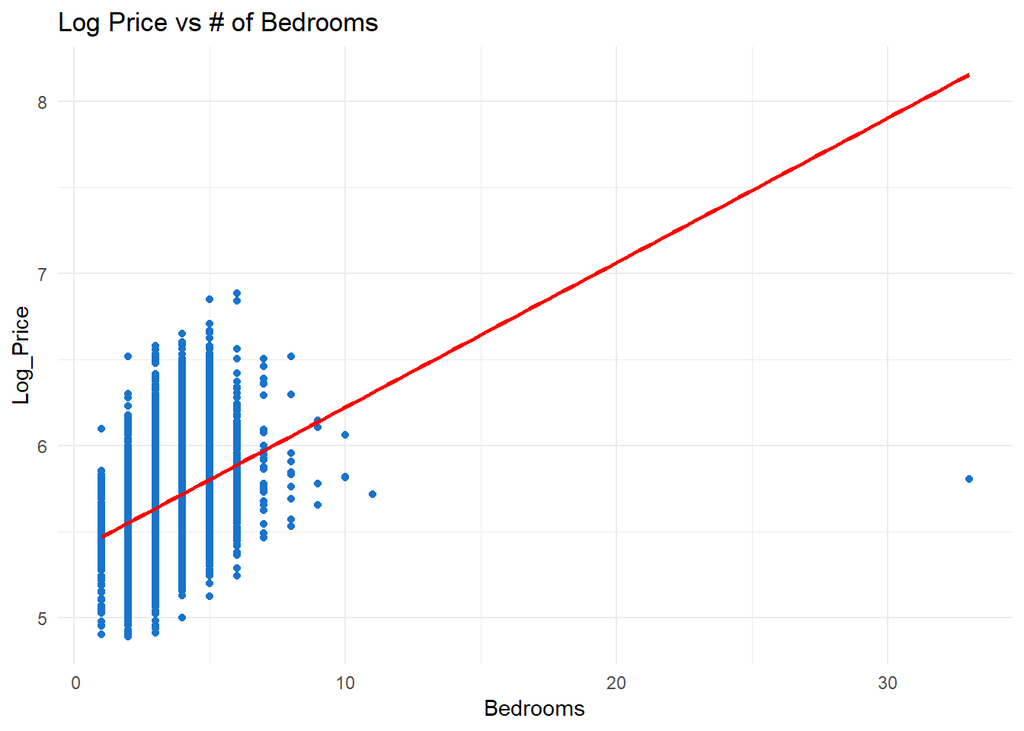

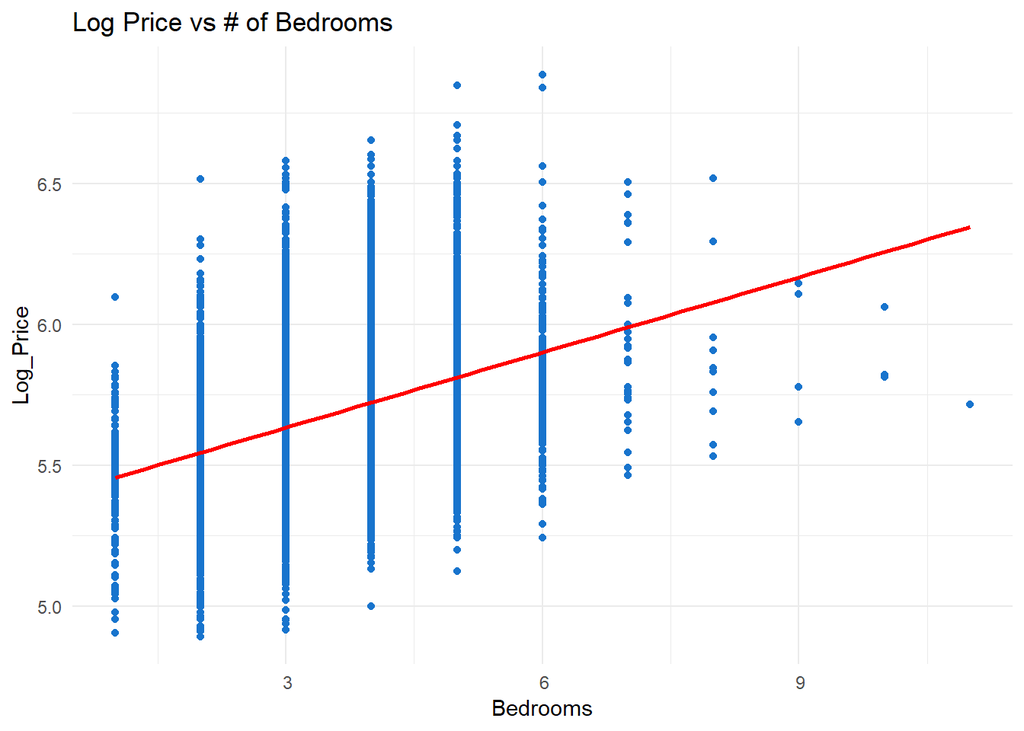

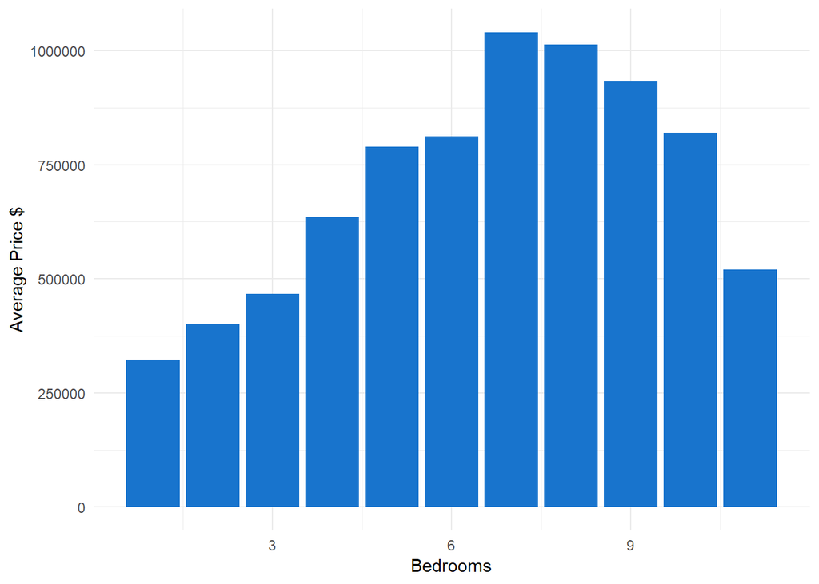

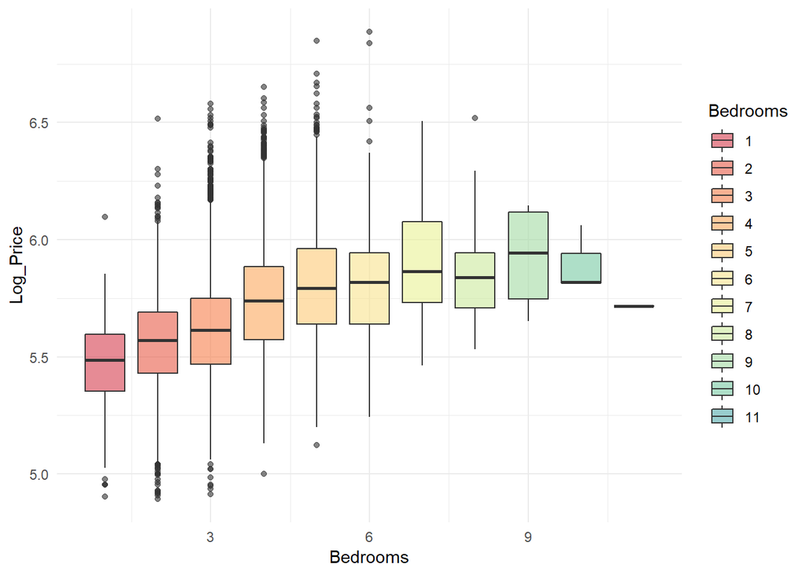

##### 7.3 Bathrooms

```
##
##  0.5 0.75    1 1.25  1.5 1.75    2 2.25  2.5 2.75    3 3.25  3.5 3.75    4
##    4   71 3851    9 1445 3048 1930 2047 5377 1185  753  589  731  155  136
## 4.25  4.5 4.75    5 5.25  5.5 5.75    6 6.25  6.5 6.75  7.5 7.75    8
##   79  100   23   21   13   10    4    6    2    2    2    1    1    2
```

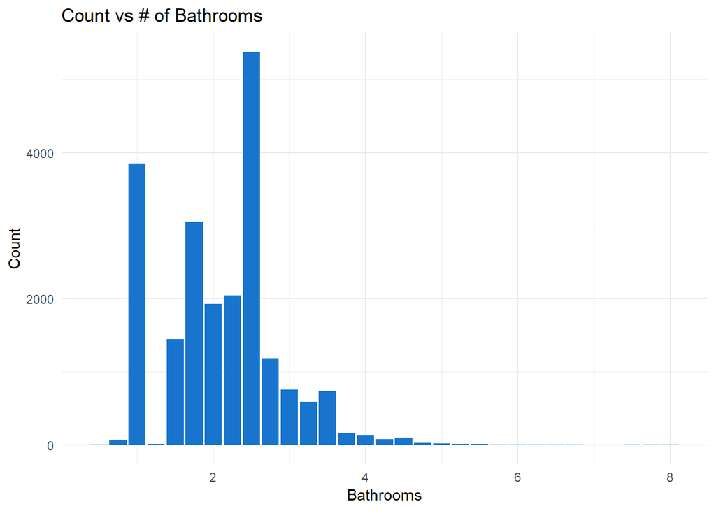

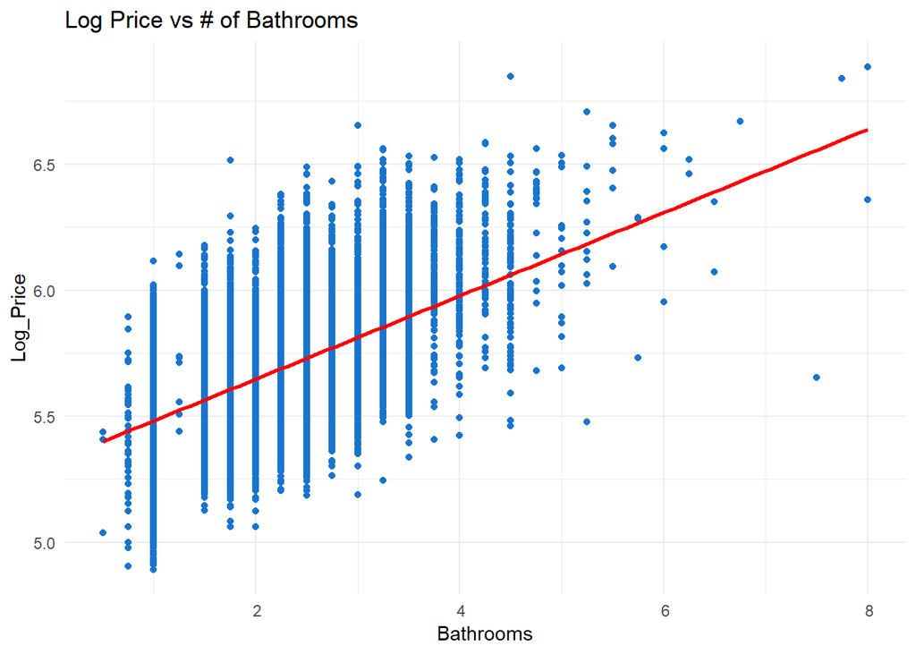

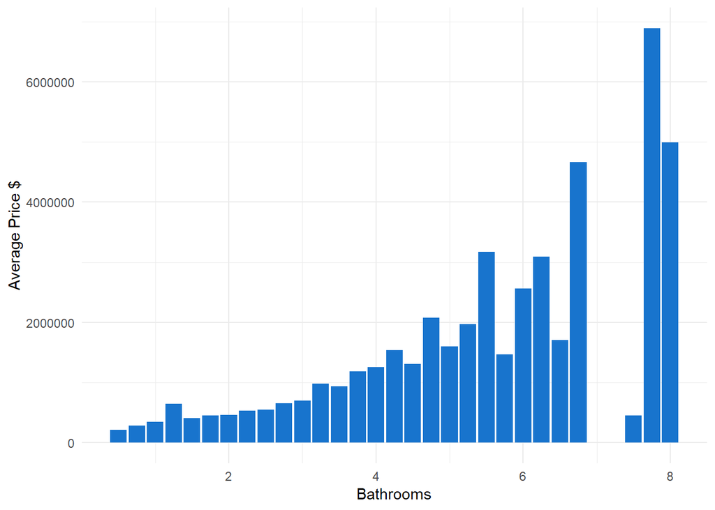

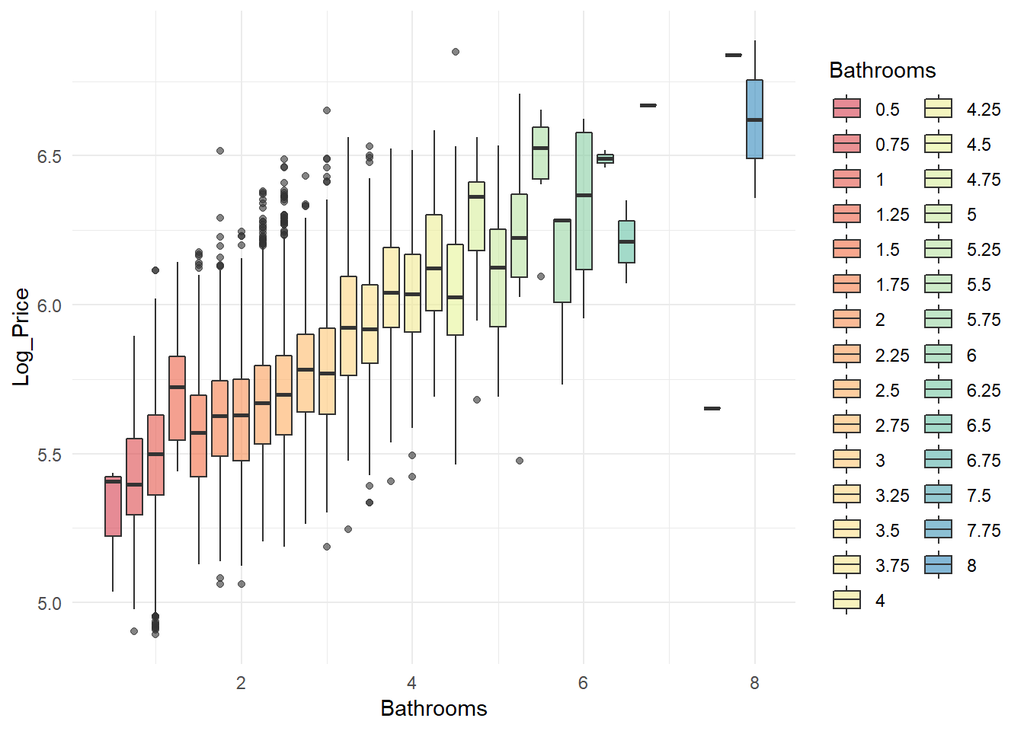

##### 7.4 Floors

```
##
##     1   1.5     2   2.5     3   3.5
## 10673  1910  8235   161   611     7
```

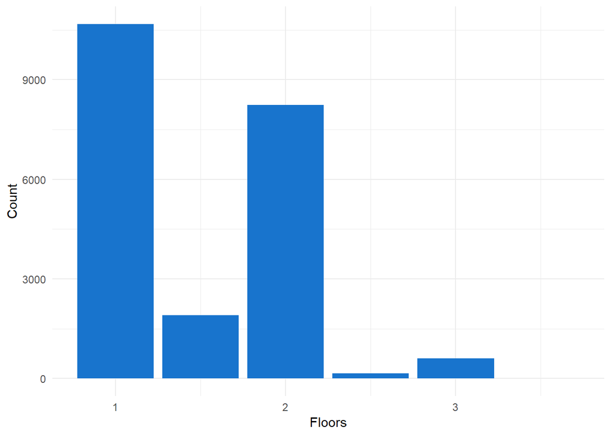

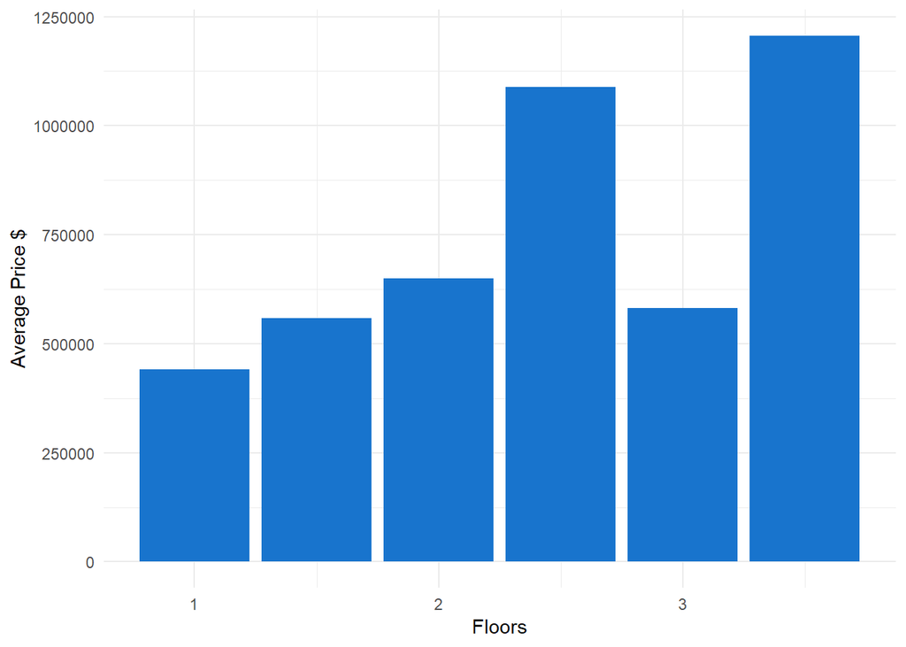

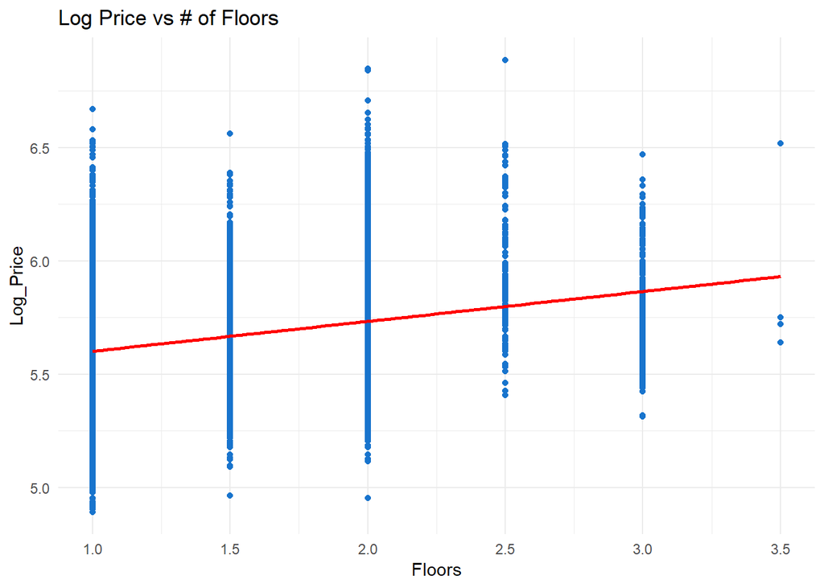

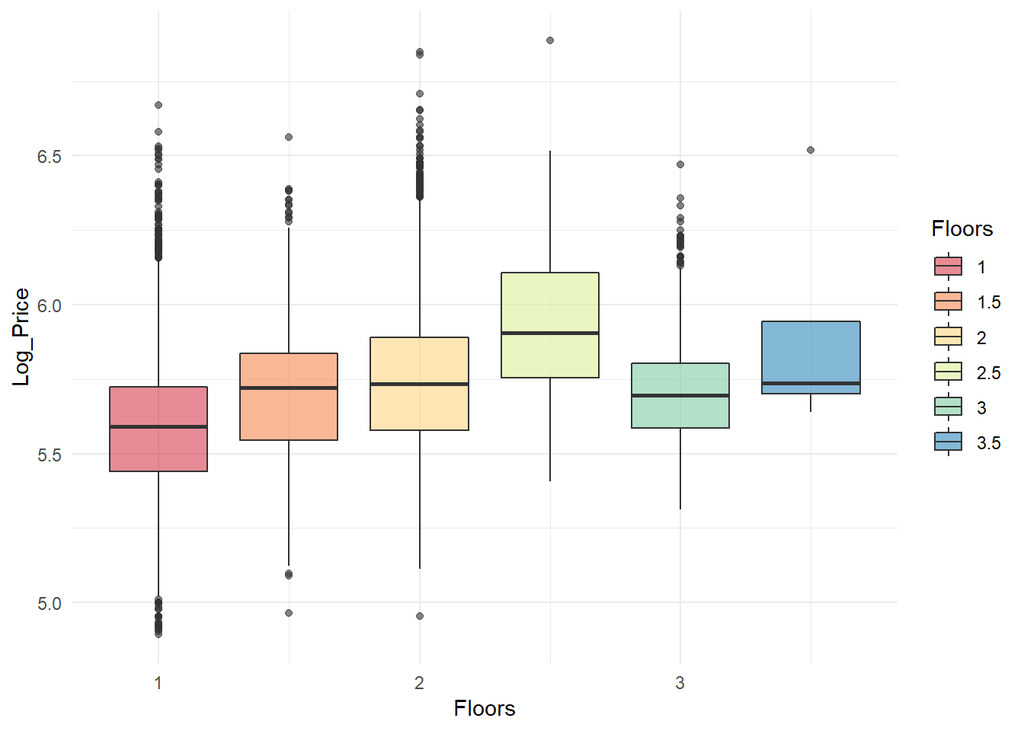

##### 7.5 House Condition

```
##
##     1     2     3     4     5
##    29   170 14020  5677  1701
```

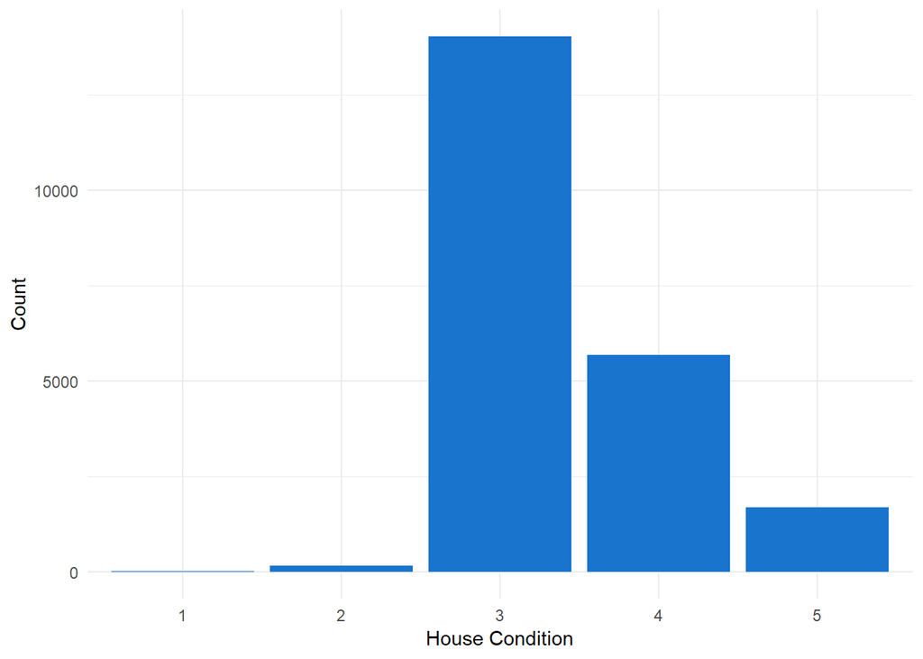

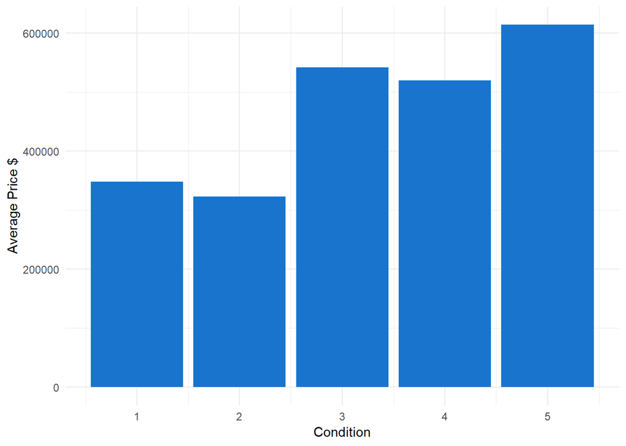

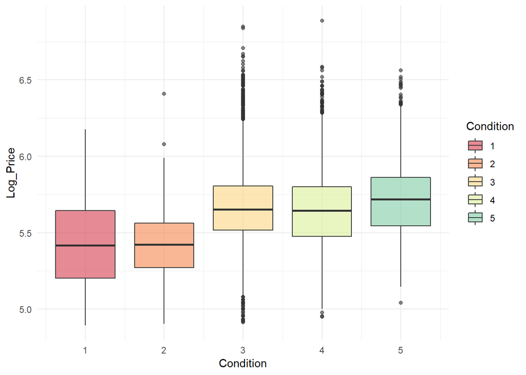